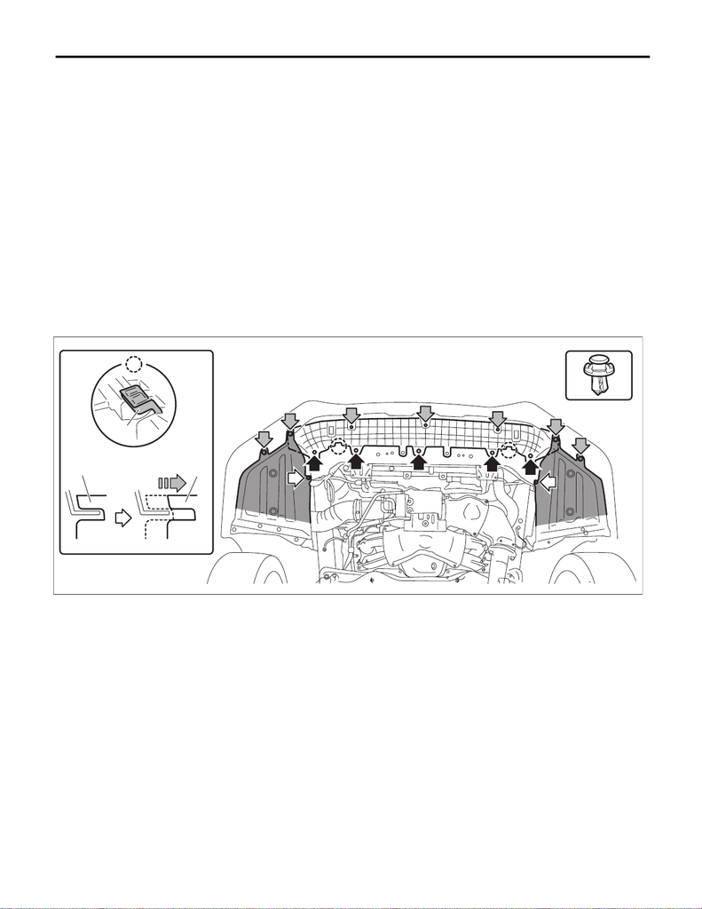

COM-5

Horn

COMMUNICATION SYSTEM

4. Horn

A: REMOVAL

1. HORN ASSY - HI

CAUTION:

When removing the horn, do not remove the bumper face – front. Bracket connection portion of the

bumper face may become damaged.

1) Disconnect the ground cable from battery. <Ref. to NT-5, BATTERY, NOTE, Note.>

NOTE:

For models other than STI model, disconnect the ground terminal from battery sensor.

2) Lift up the vehicle.

3) Remove the under cover - front. <Ref. to EI-21, REMOVAL, Front Under Cover.>

4) Remove the bracket – front center LWR.

(1) Remove the screw and clips, and turn over the mud guard - front.

(2) Remove the bolts and clips, and remove the bracket – front center LWR.

NOTE:

While entirely pushing the bracket – front center LWR forward, remove the two hooks (a) on the left and right.

AC-03585

(a)

(a)

(a)

[figure not shown]

COM-6

Horn

COMMUNICATION SYSTEM

5) Remove the horn assembly - Hi.

(1) Disconnect the connector.

(2) Remove the nut, and remove the horn assembly – Hi.

2. HORN ASSY - LO

CAUTION:

When removing the horn, do not remove the bumper face – front. Bracket connection portion of the

bumper face may become damaged.

1) Disconnect the ground cable from battery. <Ref. to NT-5, BATTERY, NOTE, Note.>

NOTE:

For models other than STI model, disconnect the ground terminal from battery sensor.

2) Remove the screw and clips, and turn over the mud guard - front on the right side.

COM00128

LI-01750

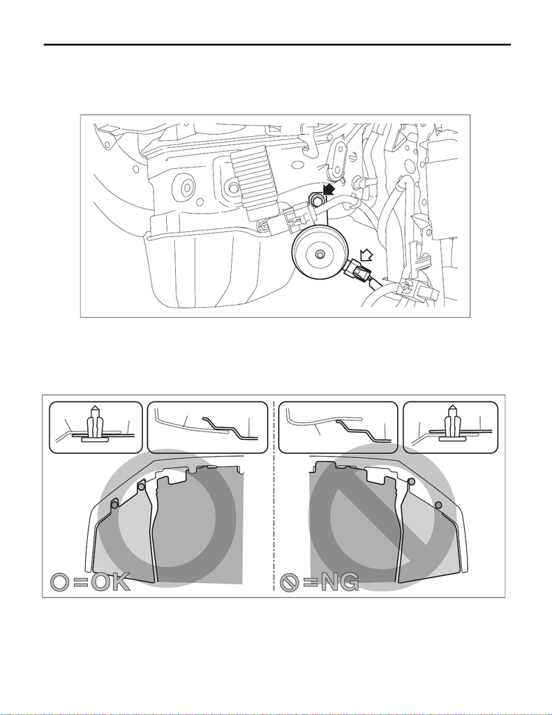

COM-7

Horn

COMMUNICATION SYSTEM

3) Remove the horn assembly - Lo.

(1) Disconnect the connector.

(2) Remove the bolt, and remove the horn assembly - Lo.

CAUTION:

The resistor may become hot. Be careful not to burn yourself.

B: INSTALLATION

1. HORN ASSY - HI

CAUTION:

Install so that the front end of the under cover (b) comes inside the bumper face - front (a), and the

front end of the mud guard (c) comes outside the bumper face - front (a).

1) Install the horn assembly - Hi.

Tightening torque:

18 N·m (1.8 kgf-m, 13.3 ft-lb)

COM00126

COM00138

(a)

(c)

(b)

(a)

(a)

(c)

(b)

(a)

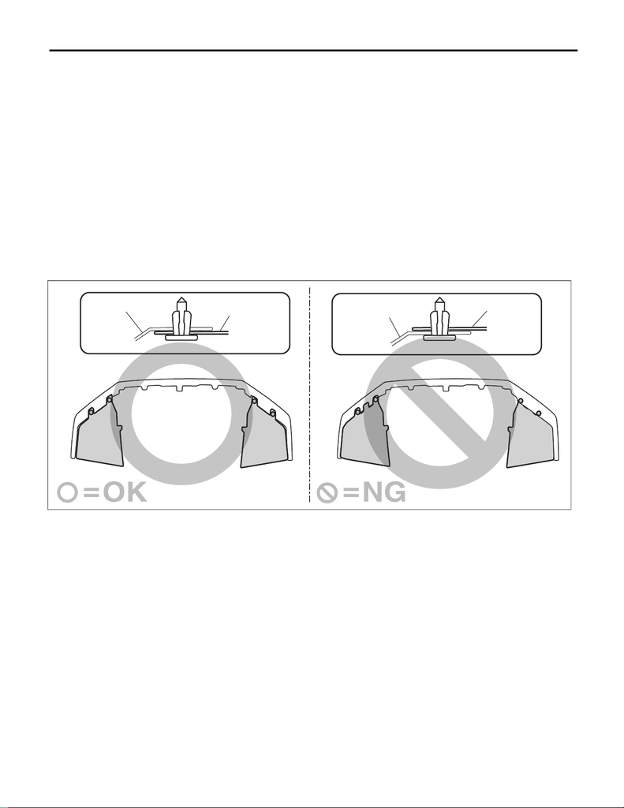

COM-8

Horn

COMMUNICATION SYSTEM

2) Install the bracket - front center LWR.

Tightening torque:

7.5 N·m (0.8 kgf-m, 5.5 ft-lb)

3) Install the mud guard - front.

4) Install the under cover - front.

Tightening torque:

18 N·m (1.8 kgf-m, 13.3 ft-lb)

5) Lower the vehicle.

6) Connect the battery ground terminal. <Ref. to NT-5, BATTERY, NOTE, Note.>

NOTE:

For models other than STI model, connect the ground terminal to battery sensor.

2. HORN ASSY - LO

CAUTION:

Install the mud guard - front so that the front end of the mud guard (b) comes outside the bumper

face - front (a).

1) Install the horn assembly - Lo.

Tightening torque:

18 N·m (1.8 kgf-m, 13.3 ft-lb)

2) Install the mud guard - front.

3) Connect the battery ground terminal. <Ref. to NT-5, BATTERY, NOTE, Note.>

NOTE:

For models other than STI model, connect the ground terminal to battery sensor.

COM00136

(a)

(b)

(a)

(b)

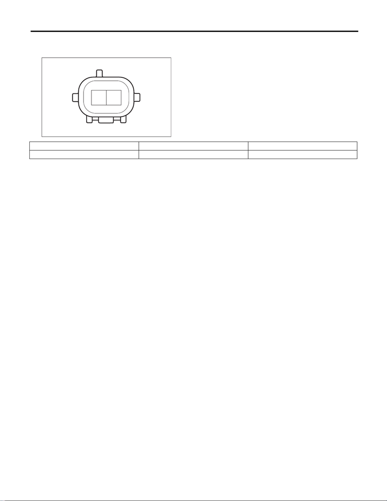

COM-9

Horn

COMMUNICATION SYSTEM

C: INSPECTION

1) Check that the horn assembly sounds when applying the battery voltage to each connector terminal.

2) If it does not operate normally, replace the horn assembly.

2 1

COM00137

Terminal No. Inspection conditions Specification

Terminal 1 (+) — Terminal 2 (–) Connect battery to the terminals Sounds